# Inferência dos dados da Wikimedia Foundation

## Introdução

A [Wikimedia Foundation](https://wikimediafoundation.org/wiki/Home) é uma organização sem fins lucrativos que encoraja o crescimento, desenvolvimento e distribuição de conteúdo de educação grátis e em múltiplas linguagens através de projetos baseados em [wiki](https://en.wikipedia.org/wiki/Wiki).

Em 2016 o [Wikimedia Discovery](https://www.mediawiki.org/wiki/Wikimedia_Discovery), um departamento da Wikimidia Foundation, abriu uma seleção de empregos para o cargo de analista de dados. Neste relatório responderemos as perguntas propostas por eles, descrita [nesta proposta de emprego](https://github.com/wikimedia-research/Discovery-Hiring-Analyst-2016):

1. Qual é nossa taxa de click geral diária? Como ela varia entre os grupos?
2. Qual resultados as pessoas tendem a tentar primeiro? Como ela muda dia a dia?
3. Qual é nossa taxa de resultados zerados diária? Como ela varia entre os grupos?

Para responder essas perguntas, utilizaremos os [dados](https://github.com/wikimedia-research/Discovery-Hiring-Analyst-2016/raw/master/events_log.csv.gz) fornecidos por eles e modificados pelo professor Nazareno Andrade utilizando um [script R](https://github.com/fpcc2/lab2-cp4-orionwinter/blob/master/code/import-events_to_searches.R). Como os dados providos pela Wikimedia são apenas uma amostra, utilizaremos bootstrap e intervalo de confiança para inferir sobre a amostra. Como os dados são de interações entre usuário e máquina, os quais são sujeitos a variabilidade humana, utilizaremos o nível de confiança de 95%.

## Descrevendo os dados

```r
set.seed(123)
library(tidyverse)
library(lubridate)
library(here)
library(scales)
library(resample)
library(boot)
```

Primeiramente vamos importar os dados:

```r
buscas <- read_csv(here::here("data/search_data.csv"))
```

Vejamos a estrutura dos dados:

```r
buscas %>%
    str(max.level = 1)
```

```
## Classes 'tbl_df', 'tbl' and 'data.frame':    136234 obs. of  9 variables:
##  $ session_id             : chr  "0000cbcb67c19c45" "0001382e027b2ea4" "0001e8bb90445cb2" "000216cf18ae1ab1" ...
##  $ search_index           : int  1 1 1 1 2 3 4 5 6 1 ...
##  $ session_length         : int  0 303 435 58 58 58 58 58 58 0 ...
##  $ session_start_timestamp: num  2.02e+13 2.02e+13 2.02e+13 2.02e+13 2.02e+13 ...
##  $ session_start_date     : POSIXct, format: "2016-03-03 15:20:45" "2016-03-07 08:49:55" ...
##  $ group                  : chr  "b" "b" "b" "a" ...
##  $ results                : int  20 18 20 20 20 20 20 20 20 1 ...
##  $ num_clicks             : int  0 1 1 0 0 0 0 0 0 0 ...
##  $ first_click            : int  NA 1 1 NA NA NA NA NA NA NA ...
##  - attr(*, "spec")=List of 2
##   ..- attr(*, "class")= chr "col_spec"
```

Existem 9 colunas nos dados sendo elas:

- session_id : Um id único identificando sessões individuais
- search_index : Um contador de buscas em uma mesma sessão ordenado cronologicamente
- session_start_timestamp: O timestamp que a sessão iniciou
- session_start_date : A data e hora que a sessão iniciou
- group : O grupo que pode ser “a” ou “b”
- results : A quantidade de resultados que a busca retornou
- num_clicks : O número de páginas que o usuário visitou a partir da busca
- first_click : A posição do link da página visitada no mecanismo de busca de páginas
- session_length : A duração em segundos da sessão

## Análise de dados exploratória

Agora vamos explorar os dados, olhando suas distribuições, valores extremos e faltantes:

### Id da sessão

Vejamos primeiro os sessions ids:

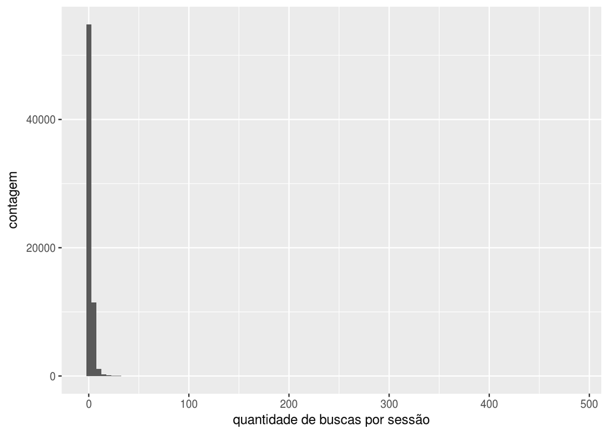

```r
buscas.por.sessao <- buscas %>%
    group_by(session_id) %>%
    summarise(contagem = n(),
              tempo.mediano.entre.consultas = median(session_start_date - lag(session_start_date),
                                                     na.rm = TRUE),
              desvio.padrao.entre.consultas = sd(session_start_date - lag(session_start_date),
                                                     na.rm = TRUE)) %>%
    arrange(-contagem)

buscas.por.sessao %>%
    ggplot(aes(x = contagem)) +
        geom_histogram(binwidth = 5) +
        labs(x = "quantidade de buscas por sessão", y = "contagem")
```

De um total de quase 68 mil sessões, a maior parte teve até 10 buscas, que estão concentradas nas duas primeiras barras. A distribuição da quantidade de buscas por sessão é bastante assimétrica e enviesada à direita.

Vejamos agora o tempo mediano entre consultas:

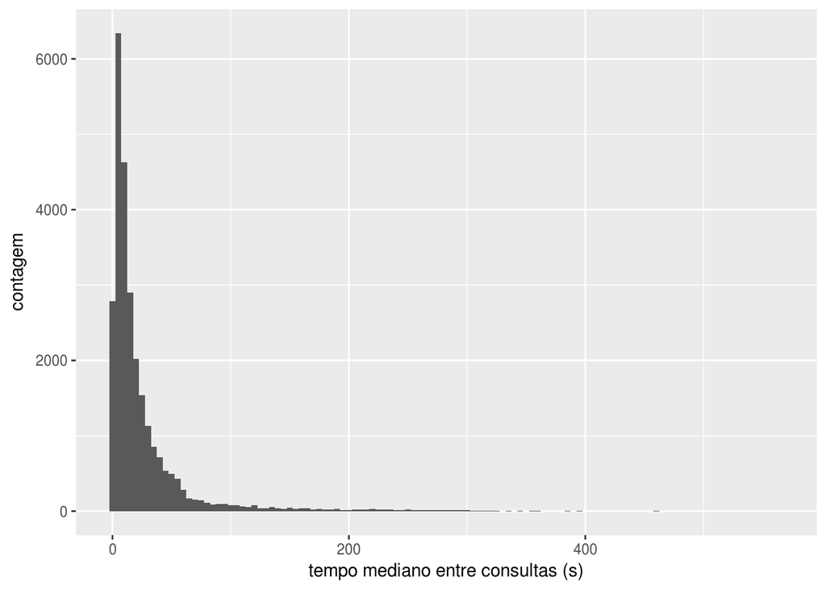

```r
buscas.por.sessao %>%
    filter(!is.na(tempo.mediano.entre.consultas)) %>%
    mutate(tempo.mediano.entre.consultas = as.integer(tempo.mediano.entre.consultas)) %>%
    ggplot(aes(x = tempo.mediano.entre.consultas)) +
        geom_histogram(binwidth = 5) +
        labs(x = "tempo mediano entre consultas (s)", y = "contagem")
```

```r
buscas.por.sessao %>%
    mutate(tempo.mediano.entre.consultas = as.integer(tempo.mediano.entre.consultas)) %>%
    pull(tempo.mediano.entre.consultas) %>%
    summary()
```

```
##    Min. 1st Qu.  Median    Mean 3rd Qu.    Max.    NA's
##    0.00    5.00   12.00   25.18   27.00  563.00   41163
```

Vemos que muitas sessões tem o tempo mediano entre consultas bastante baixo, onde 50% das sessões tem mediana de duração abaixo de 12 segundos e 75% das sessões tem mediana de duração abaixo de 27 segundos.

### Data e hora da sessão

Vamos explorar agora a data das buscas:

```r
buscas %>%
    summarise(data.inicio = min(session_start_date),
              data.fim = max(session_start_date))
```

| data.inicio | data.fim |
| --- | --- |
| 2016-03-01 00:00:02 | 2016-03-08 20:24:32 |

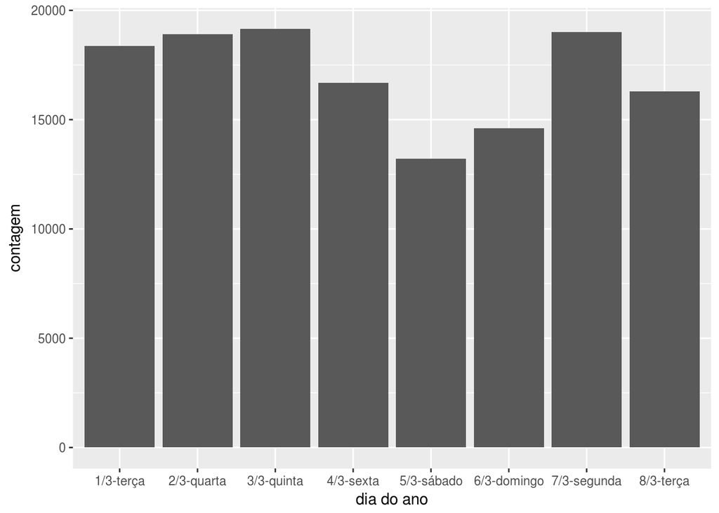

```r
buscas %>%
    mutate(dia.do.ano = paste(day(session_start_date), "/", month(session_start_date), "-", weekdays(session_start_date), sep = "")) %>%
    group_by(dia.do.ano) %>%
    count() %>%
    ggplot(aes(x = dia.do.ano, n)) +
        geom_bar(stat = "identity") +
        labs(x = "dia do ano", y = "contagem")
```

Vemos que os dados vão do dia 01/03/2016 à 08/03/2016 e que a quantidade de buscas diárias fica entre 13 e 19 mil, onde os finais de semana tem menos observações que os dias de semana. Como o dia 08/03 foi até as 20h, este tem menos observações que os outros dias de semana.

### Grupo

Vejamos agora os grupos que estão presentes nos dados.

```r
buscas %>%
    group_by(group) %>%
    summarise(total = n(),
              proporcao = total / nrow(buscas))
```

| group | total | proporcao |
| --- | --- | --- |
| a | 92056 | 0.6757197 |
| b | 44178 | 0.3242803 |

Vemos que cerca de 70% das buscas são do grupo A, enquanto cerca de 30% são do grupo B.

### Resultados

Vejamos agora quantos resultados as buscas retornam:

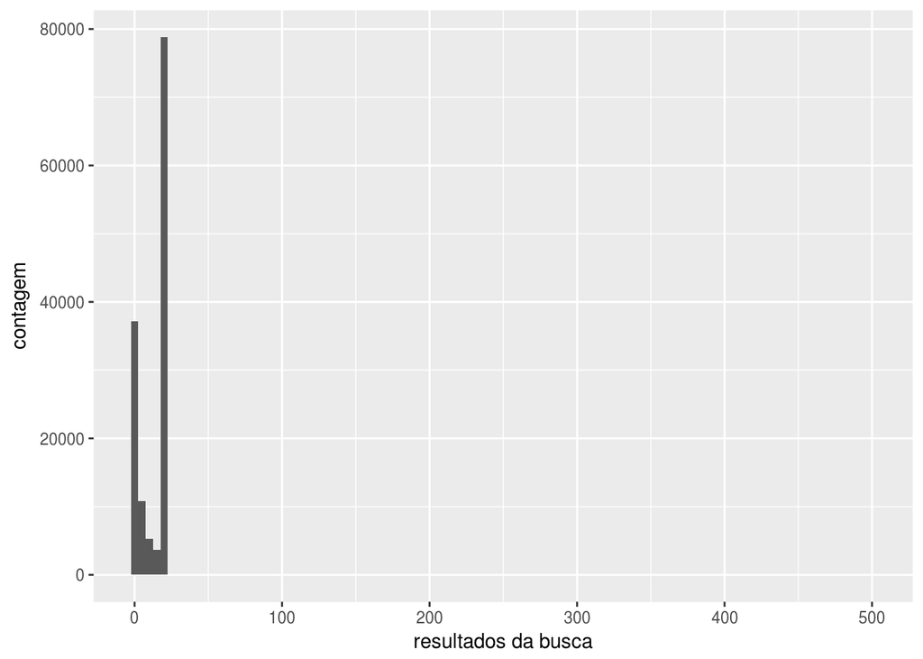

```r
buscas %>%
    ggplot(aes(x = results)) +
        geom_histogram(binwidth = 5) +
        labs(x = "resultados da busca", y = "contagem")
```

```r
buscas %>%
    summarise(minimo = min(results),
              primeiro.quartil = quantile(results, probs = .25),
              mediana = quantile(results, probs = .5),
              terceiro.quartil = quantile(results, probs = .75),
              percentil.99 = quantile(results, probs = .99)
    )
```

| minimo | primeiro.quartil | mediana | terceiro.quartil | percentil.99 |
| --- | --- | --- | --- | --- |
| 0 | 2 | 20 | 20 | 20 |

Vemos que 25% das buscas retornam até 2 resultados e que 99% das buscas retornam até 20 resultados, porém existem alguns que retornam bem mais que este valor. Vejamos quais são estes:

```r
buscas %>%
    filter(results > 20) %>%
    arrange(-results) %>%
    select(session_id, results)
```

| session_id | results |
| --- | --- |
| 03e4e90686ac43fc | 500 |
| 0706006cd5457e53 | 500 |
| 1bbdd282c7c52299 | 500 |
| 1c08a0976e7b3268 | 500 |
| 240b815b8840d794 | 500 |
| 240b815b8840d794 | 500 |
| 240b815b8840d794 | 500 |
| 349b9eaf04abc0cd | 500 |
| 4f7833c7103c698a | 500 |
| 4f7833c7103c698a | 500 |

[output cut: 399 more lines]

Vemos que existe uma quantidade considerável de buscas que retornaram mais que 20 resultados, tendo vários que retornaram até 500. Como a [api](https://www.mediawiki.org/wiki/API:Lists) informa que o limite de resultados é 10 por default, mas pode ser aumentado até 500, então não faremos nenhum processamento com os resultados.

### Número de clicks

Vejamos agora a quantidade de clicks que um usuário faz:

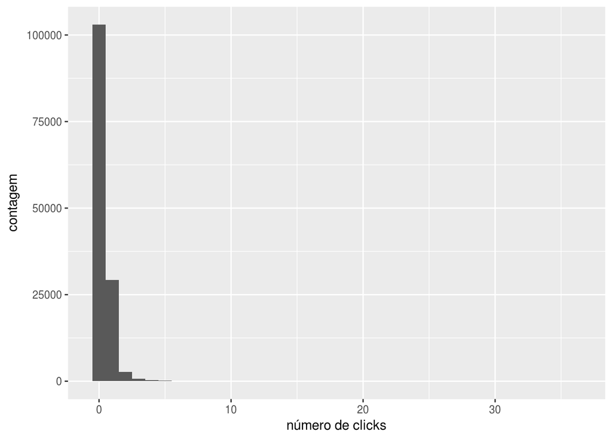

```r
buscas %>%
    ggplot(aes(x = num_clicks)) +
        geom_histogram(binwidth = 1) +
        labs(x = "número de clicks", y = "contagem")
```

```r
buscas %>%
    pull(num_clicks) %>%
    summary()
```

```
##    Min. 1st Qu.  Median    Mean 3rd Qu.    Max.
##  0.0000  0.0000  0.0000  0.2937  0.0000 36.0000
```

Vemos que a concentração maior de clicks está próxima de zero, onde 75% das buscas não resulta em nenhum click, porém a distribuição tem uma cauda longa a direita, tendo um caso que o usuário clicou mais de 30 vezes nos itens da busca.

Podemos ver abaixo que existem quantidades de clicks superior à quantidade de resultados, inclusive quando a quantidade de resultados é zero. Como um usuário pode clicar em uma página, depois em outra e em seguida voltar à primeira, removeremos apenas as observações que o número de clicks for superior a quantidade de resultados e o número de resultados for zero, visto que um usuário não pode clicar em um link se a busca não retornou nada.

```r
buscas %>%
    filter(num_clicks > results) %>%
    arrange(results) %>%
    select(session_id, num_clicks, results)
```

| session_id | num_clicks | results |
| --- | --- | --- |
| 0c02236a143c5f2d | 1 | 0 |
| 3ed6cf242cfef08e | 3 | 0 |
| 40c841015011ca78 | 1 | 0 |
| 5cd911a51593a318 | 3 | 0 |
| 802227a5617ada1a | 1 | 0 |
| c87ebed483880c25 | 1 | 0 |
| e408f661309b14e5 | 1 | 0 |
| 01a0d2b3d48278a7 | 5 | 1 |
| 02aa6878fcdf6c58 | 3 | 1 |
| 056145b0bb0d8b0a | 2 | 1 |

[output cut: 98 more lines]

```r
buscas.filtradas <- buscas %>%
    filter(!(num_clicks > results & results == 0))
```

### Índice do primeiro click

Vejamos agora a distribuição da posição do item que o usuário clicou no mecanismo de busca:

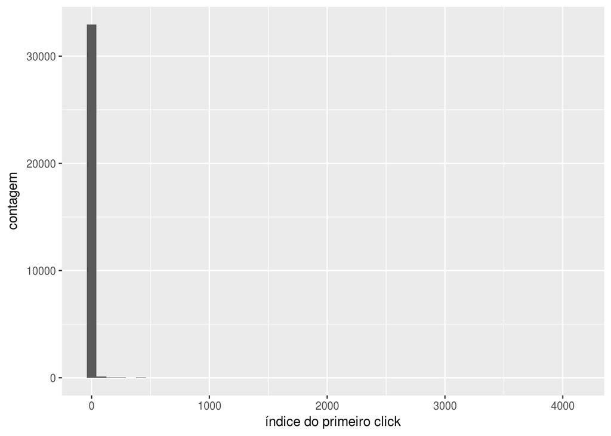

```r
buscas %>%
    filter(!is.na(first_click)) %>%
        ggplot(aes(x = first_click)) +
            geom_histogram(bins = 50) +
            labs(x = "índice do primeiro click", y = "contagem")
```

Vemos que a maior parte dos indices tem valor baixo, mas existem alguns com valor acima de 4000. Pesquisando um pouco sobre o mecanismo de busca, verificamos que o índice do primeiro click pode ser maior que a quantidade de resultados, pois o resultado pode ser apenas uma página do total de resultados que uma busca fornece.

Podemos verificar isso no exemplo abaixo, onde o usuário fez uma busca que tinha um total de 32 resultados, mas o limite por página era 20, logo a primeira página da busca tinha 20 itens e a segunda 12. Na primeira página ele não clicou em nenhum item, mas na segunda página ele clicou no 12º item, que era o 32º item da pesquisa.

```r
buscas.filtradas %>%
    filter(session_id == "0d050fd8343f9ab7") %>%
    select(session_id, session_start_date, results, num_clicks, first_click)
```

| session_id | session_start_date | results | num_clicks | first_click |
| --- | --- | --- | --- | --- |
| 0d050fd8343f9ab7 | 2016-03-05 11:47:36 | 20 | 0 | NA |
| 0d050fd8343f9ab7 | 2016-03-05 11:48:03 | 12 | 1 | 32 |

### Duração da sessão

Por último, veremos quanto tempo demora as sessões, vendo sua distribuição:

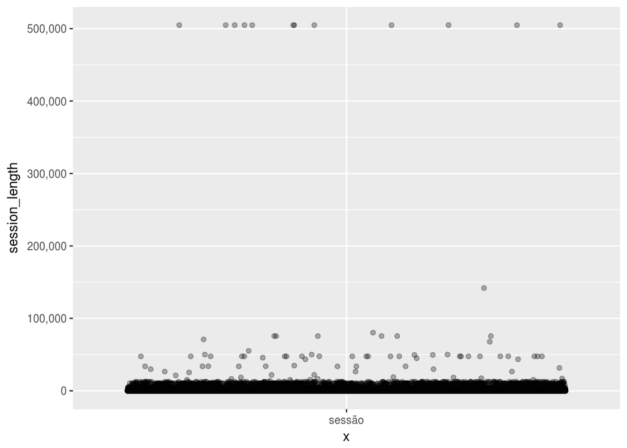

```r
buscas.filtradas %>%
    ggplot(aes(x = "sessão", y = session_length)) +
        geom_jitter(alpha = 0.3) +
        scale_y_continuous(labels = comma)
```

Vemos que grande parte das sessões tem duração baixa, visto a grande concentração de pontos abaixo.

Como a sessão não tem nenhuma restrição de duração, não faremos nenhum filtro com a mesma.

## Respondendo a primeira pergunta

Relembrando, a primeira pergunta a ser respondida é a seguinte:

**Qual é nossa taxa de click geral diária? Como ela varia entre os grupos?**

Consideraremos que a taxa de click geral diária é a proporção das sessões em que o usuário clicou em pelo menos um item mostrado.

Vejamos como é esta taxa, utilizando inferência:

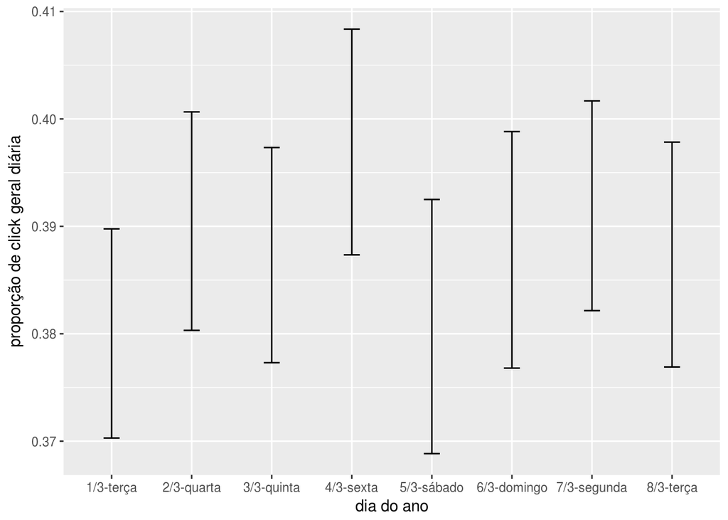

```r
clicks <- buscas.filtradas %>%
    group_by(session_id) %>%
    summarise(
        start_date = first(session_start_date),
        dia.do.ano = paste(day(start_date), "/", month(start_date), "-", weekdays(start_date), sep = ""),
        teve_click = sum(num_clicks, na.rm = TRUE) > 0,
        group = first(group)
    ) %>%
    ungroup()

prop.maior.zero <- function(value, i) {
    return(sum(value[i]) / length(value[i]))
}

boot.dia.a.dia <- clicks %>%
    filter(!is.na(teve_click)) %>%
    group_by(dia.do.ano) %>%
    summarise(
        boot = list(boot(teve_click, prop.maior.zero, R = 2000))
    )

ics.dia.a.dia <- boot.dia.a.dia %>%
    group_by(dia.do.ano) %>%
    mutate(
        ci = list(boot.ci(boot.out = boot[[1]], conf = 0.95, type = "basic")),
        lower = ci[[1]][[4]][4],
        upper = ci[[1]][[4]][5]
    ) %>%
    select(-ci)

ics.dia.a.dia %>%
  ggplot(aes(x = dia.do.ano, ymin = lower, ymax = upper)) +
    geom_errorbar(width = .2) +
    labs(x = "dia do ano", y = "proporção de click geral diária")
```

Como podemos ver, a taxa geral de clicks diária é razoavelmente baixa, visto que pode variar entre 37% e 41%, além de não existir diferença significativa, com 95% de confiança, da proporção de pesquisas que geraram click entre os dias. Ou seja, a maioria das sessões de busca, não resulta em nenhum click, visto que em nenhum dia a proporção de pesquisas que tiveram click superou 50%.

Vejamos como esta taxa geral de clicks diária varia entre os grupos:

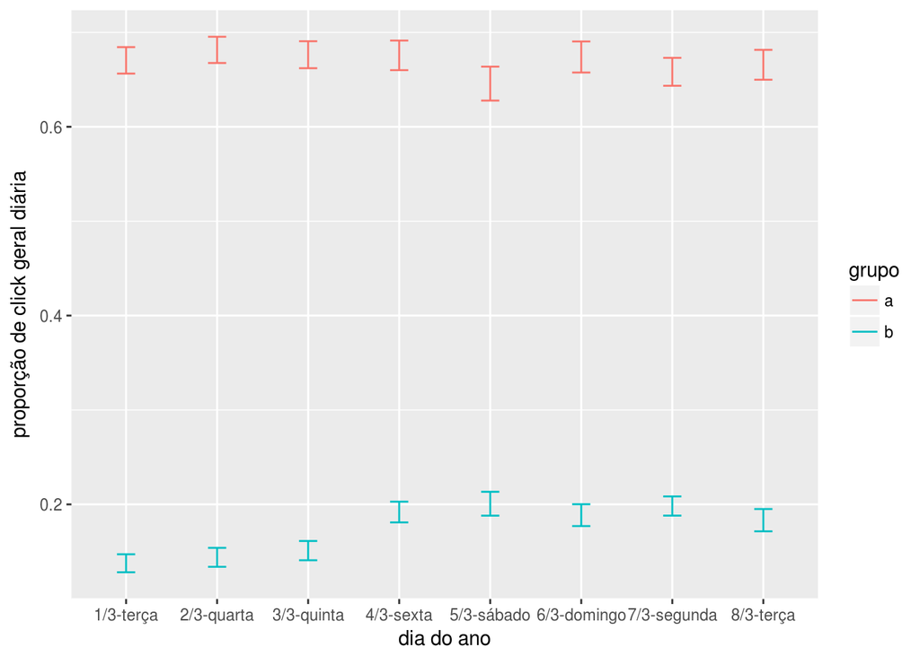

```r
boot.dia.a.dia.grupo <- clicks %>%
    filter(!is.na(teve_click)) %>%
    group_by(dia.do.ano, group) %>%
    summarise(
        boot = list(boot(teve_click, prop.maior.zero, R = 2000))
    )

ics.dia.a.dia.grupo <- boot.dia.a.dia.grupo %>%
    group_by(dia.do.ano, group) %>%
    mutate(
        ci = list(boot.ci(boot.out = boot[[1]], conf = 0.95, type = "basic")),
        lower = ci[[1]][[4]][4],
        upper = ci[[1]][[4]][5]
    ) %>%
    select(-ci)

ics.dia.a.dia.grupo %>%
  ggplot(aes(x = dia.do.ano, ymin = lower, ymax = upper, color = group)) +
    geom_errorbar(width = .2) +
    labs(x = "dia do ano", y = "proporção de click geral diária", color = "grupo")
```

Vemos que existe uma diferença estatisticamente relevante, com 95% de confiança, da taxa geral de clicks diária entre os grupos, visto que o intervalo de confiança do grupo A é sempre acima do grupo B, independente do dia.

Com isso concluímos que a taxa de click geral diária fica entre 37% e 41%, mas quando variamos entre os grupos, percebemos que a taxa do grupo A fica entre cerca de 63% e 69%, enquanto a taxa do grupo B fica entre 12% e 21%, com 95% de confiança. Logo existe uma diferença significativa entre o grupo A e o grupo B, com 95% de confiança. Além do mais, o grupo A tem a taxa de click geral diária mais de três vezes maior que o grupo B, independente do dia.

### Verificando o método utilizado

Para testarmos o método utilizado acima, verificaremos se existe uma diferença entre a taxa de clicks geral diária da metade das sessões do grupo A, com a outra metade do grupo A, separadas aleatóriamente. Deste modo, como estaremos comparando observações do mesmo grupo, é esperado que não exista diferença significativa.

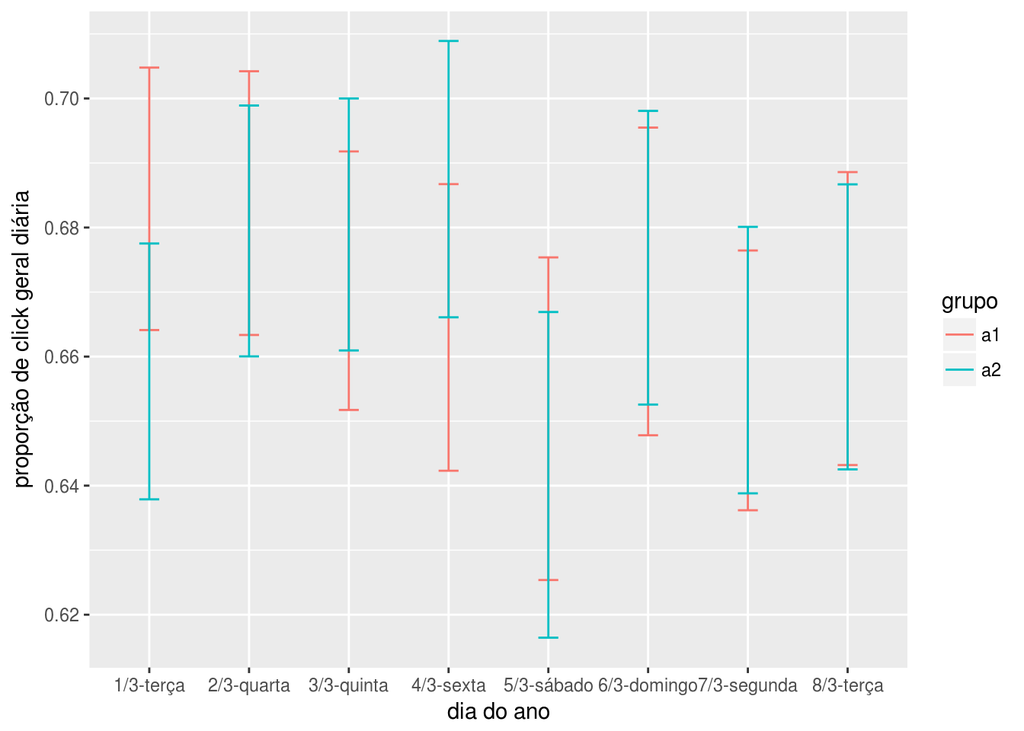

```r
clicks.group.a <- clicks %>%
    filter(group == "a")

a1.group.indexes <- sample(1:nrow(clicks.group.a), size = floor(nrow(clicks.group.a) / 2))

clicks.group.a <- clicks.group.a %>%
    mutate(new.group = ifelse(row_number() %in% a1.group.indexes, "a1", "a2"))

boot.dia.a.dia.grupo.a <- clicks.group.a %>%
    filter(!is.na(teve_click)) %>%
    group_by(dia.do.ano, new.group) %>%
    summarise(
        boot = list(boot(teve_click, prop.maior.zero, R = 2000))
    )

ics.dia.a.dia.grupo.a <- boot.dia.a.dia.grupo.a %>%
    group_by(dia.do.ano, new.group) %>%
    mutate(
        ci = list(boot.ci(boot.out = boot[[1]], conf = 0.95, type = "basic")),
        lower = ci[[1]][[4]][4],
        upper = ci[[1]][[4]][5]
    ) %>%
    select(-ci)

ics.dia.a.dia.grupo.a %>%
  ggplot(aes(x = dia.do.ano, ymin = lower, ymax = upper, color = new.group)) +
    geom_errorbar(width = .2) +
    labs(x = "dia do ano", y = "proporção de click geral diária", color = "grupo")
```

Como esperado concluímos que não existe diferença significativa entre as taxas de click geral diária entre observações do mesmo grupo, com 95% de confiança, visto a sobreposição dos intervalos de confiança em todos os dias.

## Respondendo a segunda pergunta

Relembrando, a segunda pergunta a ser respondida é a seguinte:

**Qual resultados as pessoas tendem a tentar primeiro? Como ela muda dia a dia?**

Para responder esta pergunta veremos primeiramente a distribuição dos valores do índice do primeiro click, para isso, vamos filtrar as buscas que os usuário não clicaram:

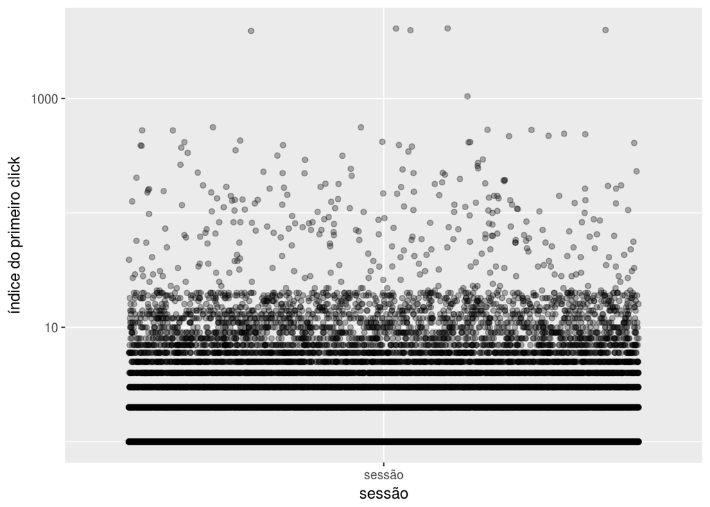

```r
buscas.com.click <- buscas.filtradas %>%
    filter(!is.na(first_click))

buscas.com.click %>%
    ggplot(aes(x = "sessão", y = first_click)) +
        geom_jitter(alpha = 0.3) +
        labs(x = "sessão", y = "índice do primeiro click") +
        scale_y_log10()
```

Vamos agora inferir quais resultados as pessoas tendem a clicar primeiro baseado na amostra dos dados, aplicando bootstrap na amostra e medindo a média do índice do primeiro click, com 95% de confiança:

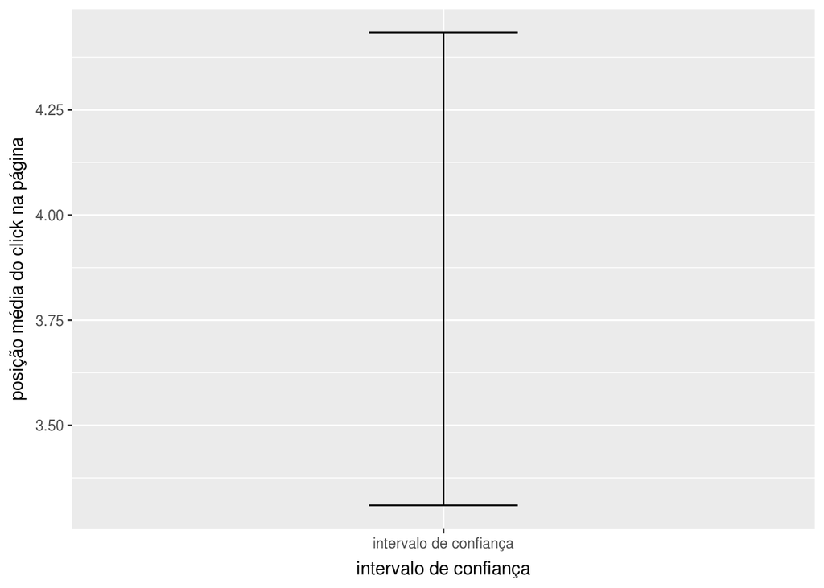

```r
media.amostra <- function(value, i) {
    mean(value[i])
}

boot.click <- boot(data = buscas.com.click$first_click,
         statistic = media.amostra,
         R = 5000)

click.ci <- boot.ci(boot.out = boot.click, conf = 0.95, type = "basic")

click.ci.df <- data.frame(lower = click.ci$basic[[4]], upper = click.ci$basic[[5]])

click.ci.df %>%
  ggplot(aes(x = "intervalo de confiança", ymin = lower, ymax = upper)) +
    geom_errorbar(width = .2) +
    labs(x = "intervalo de confiança", y = "posição média do click na página")
```

Podemos verificar que com 95% de confiança, a posição média do índice do primeiro click na página está entre 3.28 e 4.42.

Vejamos se a posição média do primeiro click na página varia entre os dias:

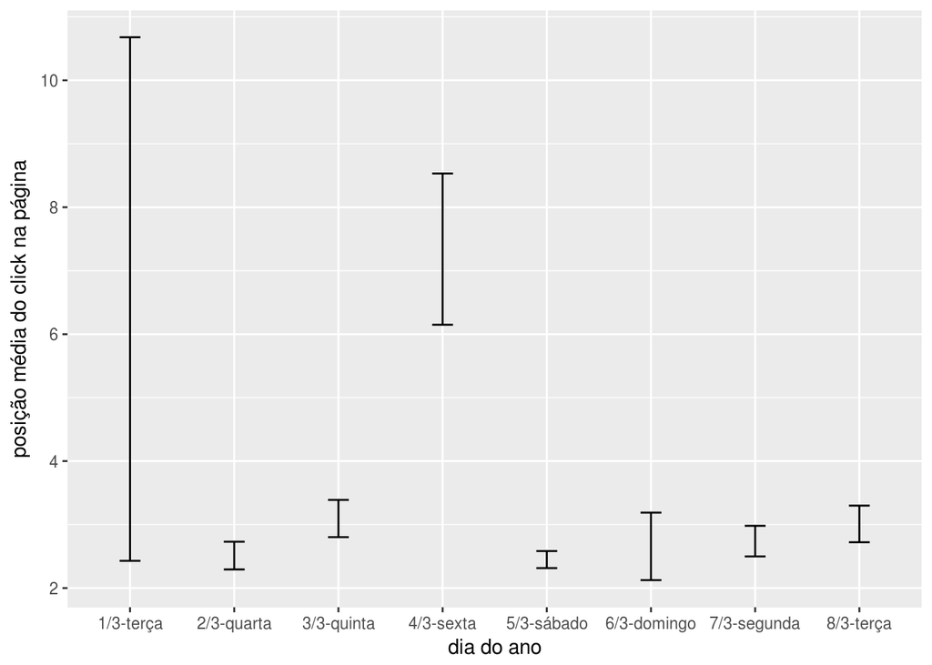

```r
boot.dia.a.dia <- buscas.com.click %>%
    rowwise() %>%
    mutate(
        start_date = first(session_start_date),
        dia.do.ano = paste(day(start_date), "/", month(start_date), "-", weekdays(start_date), sep = "")
    ) %>%
    group_by(dia.do.ano) %>%
    summarise(
        boot = list(boot(first_click, media.amostra, R = 5000))
    )

ics.dia.a.dia <- boot.dia.a.dia %>%
    group_by(dia.do.ano) %>%
    mutate(
        ci = list(boot.ci(boot.out = boot[[1]], conf = 0.95, type = "basic")),
        lower = ci[[1]][[4]][4],
        upper = ci[[1]][[4]][5]
    ) %>%
    select(-ci)

ics.dia.a.dia %>%
  ggplot(aes(x = dia.do.ano, ymin = lower, ymax = upper)) +
    geom_errorbar(width = .2) +
    labs(x = "dia do ano", y = "posição média do click na página")
```

Como podemos ver acima, não existe nenhum dia em que a posição do primeiro click se destacou significativamente, com 95% de confiança, de todos os demais. Porém, podemos verificar que o dia 04/03 teve posição média do primeiro click superior aos demais itens, com exclusão do dia 01/03. Além disso, podemos observar que o dia 05/03 teve posição do primeiro click menor que o dia 03/03 e que o dia 08/03, com 95% de confiança, porém não foi uma diferença tão absurda.

Com isso, concluímos que no geral, a posição média do índice do primeiro click se encontra entre 3.28 e 4.42, com 95% de confiança. Ao analisar dia a dia, excluindo o dia 01/03 e 04/03, a posição média é baixa, visto que a posição média para o primeiro click se encontra até o quarto elemento da página, com 95% de confiança. Vale ressaltar que utilizamos a média para verificar a tendência central, medida esta que é sensível à outliers.

## Respondendo a terceira pergunta

Relembrando, a terceira pergunta a ser respondida é a seguinte:

**Qual é nossa taxa de resultados zerados diária? Como ela varia entre os grupos?**

Para isso, veremos a taxa de resultados zerados diariamente, utilizando intervalos de confiança para inferir sobre a taxa da população a partir da amostra.

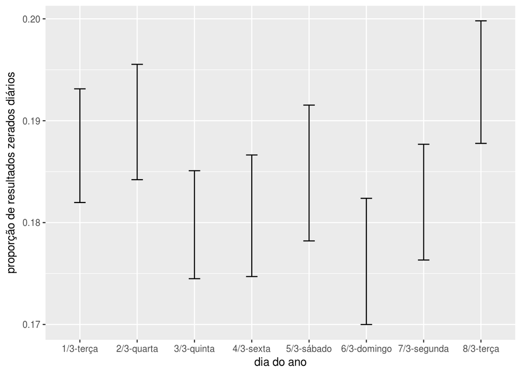

```r
prop.zero <- function(value, i) {
    return(sum(value[i] == 0) / length(value[i]))
}

boot.dia.a.dia <- buscas.filtradas %>%
    filter(!is.na(results)) %>%
    rowwise() %>%
    mutate(
        start_date = first(session_start_date),
        dia.do.ano = paste(day(start_date), "/", month(start_date), "-", weekdays(start_date), sep = "")
    ) %>%
    group_by(dia.do.ano) %>%
    summarise(
        boot = list(boot(results, prop.zero, R = 5000))
    )

ics.dia.a.dia <- boot.dia.a.dia %>%
    group_by(dia.do.ano) %>%
    mutate(
        ci = list(boot.ci(boot.out = boot[[1]], conf = 0.95, type = "basic")),
        lower = ci[[1]][[4]][4],
        upper = ci[[1]][[4]][5]
    ) %>%
    select(-ci)

ics.dia.a.dia %>%
  ggplot(aes(x = dia.do.ano, ymin = lower, ymax = upper)) +
    geom_errorbar(width = .2) +
    labs(x = "dia do ano", y = "proporção de resultados zerados diários")
```

Como podemos ver, a proporção de resultados zerados diário fica entre 0.17 e 0.20, com 95% de confiança, e não existe um dia da semana que tem uma taxa de resultado zerado diário maior que todos os demais. Contudo, podemos observar que o dia 08/03 possui uma taxa maior que o dia 03, 04, 06 e 07, com 95% de confiança, apesar de não ser uma diferença muito grande.

Vejamos se essa taxa de resultados zerados muda de acordo com o grupo:

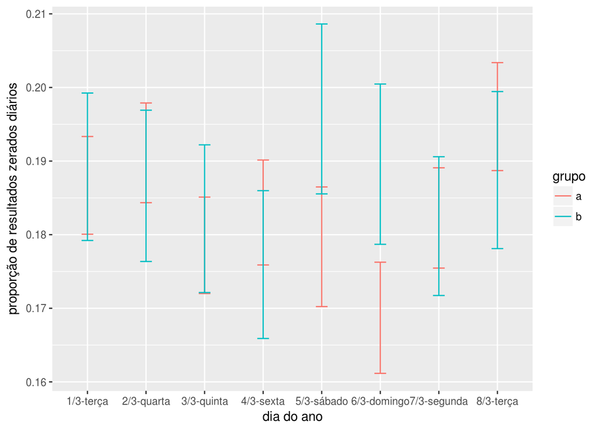

```r
boot.dia.a.dia <- buscas.filtradas %>%
    filter(!is.na(results)) %>%
    rowwise() %>%
    mutate(
        start_date = first(session_start_date),
        dia.do.ano = paste(day(start_date), "/", month(start_date), "-", weekdays(start_date), sep = "")
    ) %>%
    group_by(dia.do.ano, group) %>%
    summarise(
        boot = list(boot(results, prop.zero, R = 5000))
    )

ics.dia.a.dia <- boot.dia.a.dia %>%
    group_by(dia.do.ano, group) %>%
    mutate(
        ci = list(boot.ci(boot.out = boot[[1]], conf = 0.95, type = "basic")),
        lower = ci[[1]][[4]][4],
        upper = ci[[1]][[4]][5]
    ) %>%
    select(-ci)

ics.dia.a.dia %>%
  ggplot(aes(x = dia.do.ano, ymin = lower, ymax = upper, color = group)) +
    geom_errorbar(width = .2) +
    labs(x = "dia do ano", y = "proporção de resultados zerados diários", color = "grupo")
```

Como podemos ver, com exclusão do dia 06/03, em todos os dias não existe diferença entre a proporção de resultados zerados diários.

Com isso, concluímos que a taxa de resultados zerados fica entre 16% e 21%, com 95% de confiança, e não existe diferença significativa entre os grupos, com excessão do dia 06/03, onde grupo b tem mais resultados zerados.